# Car Accident Data

Team 8

4/17/2020

Loading the data:

```r
library(readr)
library(dplyr)
library(tidyr)
library(tidyverse)
library(lubridate)
```

```r
library(ggplot2)
crashData <- read_csv('US_Accidents_Dec19.csv')
population <- read_csv('co-est2019-alldata.csv')
```

Cleaning the accident data and then joining two dataframes:

```r
final <- left_join(population, crashData, by=c('County'))
```

Main Question:

(Charlie) How do traffic accident rates compare between different regions in the US, and what variables in the dataset have the greatest association with accident rates that may cause these differences?

```r
crashByState <- final %>% count(State) %>% filter(State != 'DC')
states <- map_data("state")
#state population data
statePop <- read_csv('StatePop.csv') %>%
  select('NAME', 'POPESTIMATE2019') %>% mutate(POPESTIMATE2019STATE = POPESTIMATE2019) %>% select(-POPESTIMATE2019)
#Format/Clean

statePop <- statePop[c(2:9,11:52), ]
#convert from "alabama" to "AL" to match crashByState format.
statePop$NAME <- statePop$NAME %>% tolower()
stateName <- state.name %>% tolower()
statePop$State <- state.abb[match(statePop$NAME, stateName)]
statePop <- statePop %>% select(-NAME)
nomatch1 <- crashByState %>% anti_join(statePop, by='State')
unique(nomatch1$State) #Nothing missing.
```

```
## character(0)
```

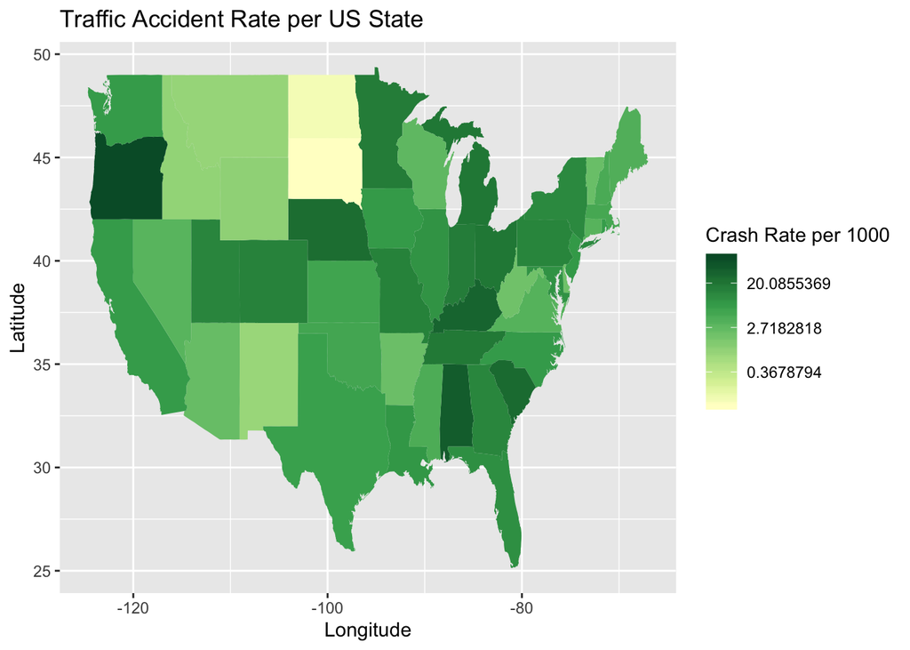

```r
states$State <- state.abb[match(states$region, stateName)]
states <- states %>% select(-'region', -'subregion')
crashByState <- crashByState %>% left_join(states, by='State')
crashByState <- crashByState %>% left_join(statePop, by='State')
crashByState %>% ggplot(aes(x=long, y=lat)) + geom_polygon(aes(group=group, fill= n / POPESTIMATE2019STATE * 1000)) + scale_fill_distiller(trans='log', palette = 'YlGn', direction = 1) + xlab("Longitude") + ylab("Latitude") + ggtitle("Traffic Accident Rate per US State") + labs(fill="Crash Rate per 1000")
```

Sub Questions:

(Cole) 1. Does the population of states and counties affect accident rates, and in the counties with the highest populations does rush hour traffic times affect accident rates?

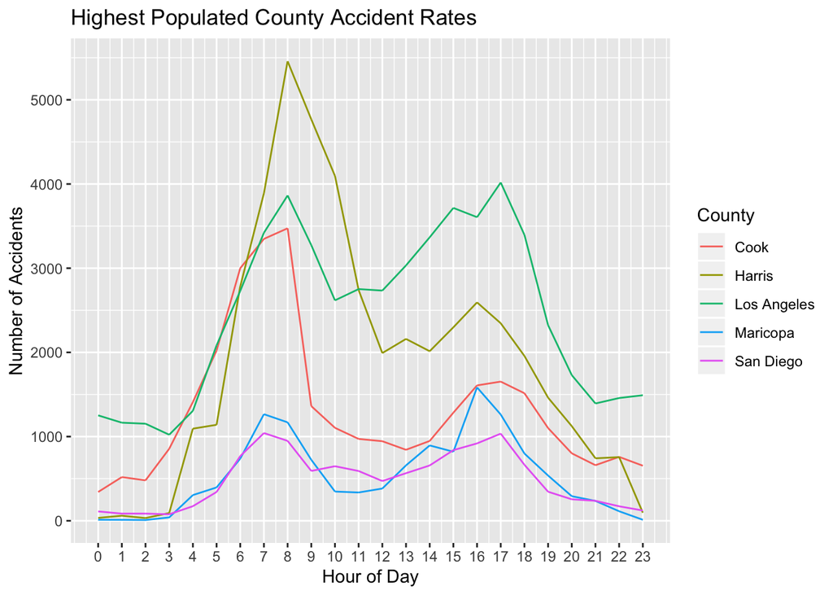

```r
q1 <- final %>% filter(County %in% c('Los Angeles','Cook','Harris','Maricopa','San Diego')) %>% group_by(Hour,County) %>% mutate(CountHour = n())
ggplot(q1, aes(x = Hour, y = CountHour)) + scale_y_continuous(breaks = seq(0, 6000, 1000),labels = function(x) format(x, scientific = FALSE)) + scale_x_continuous(breaks = seq(0, 23, 1)) + labs(title="Highest Populated County Accident Rates", x="Hour of Day", y="Number of Accidents",color="County") + geom_line(aes(color = factor(County)))
```

(Jake) 2. Are traffic accidents more common in the day or night and in turn does a higher or lower latitude have any correlation to the amount of traffic accidents that occur?

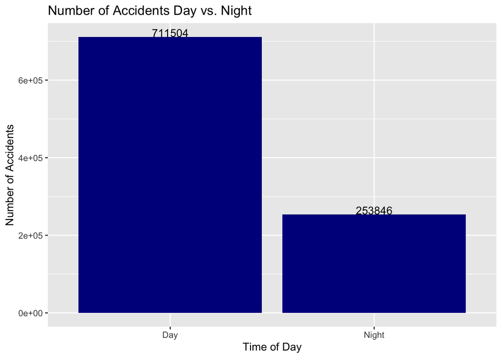

```r
JakeCrash2 <- crashData
JakeCrash2$Sunrise_Sunset <- factor(JakeCrash2$Sunrise_Sunset)
JakeCrash2 %>% group_by(Sunrise_Sunset) %>% summarize(Num_Accidents = n()) %>% ggplot(aes(x = Sunrise_Sunset, y =Num_Accidents)) + geom_bar(stat= 'identity', fill = "blue4") + geom_text(aes(label = Num_Accidents), colour = "Black", vjust = 0) + ggtitle("Number of Accidents Day vs. Night") + xlab("Time of Day") + ylab("Number of Accidents")
```

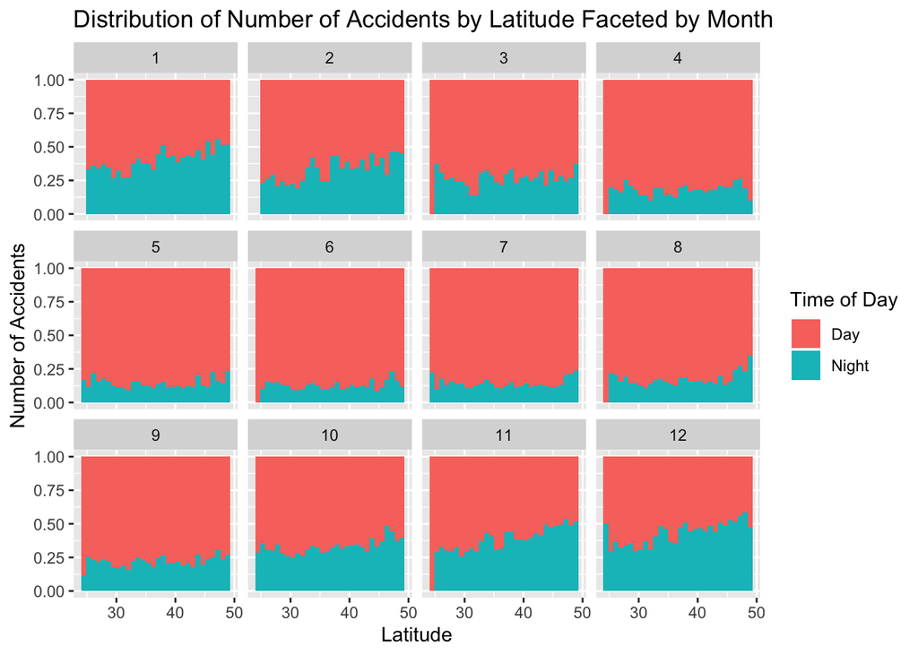

```r
#There are more accident occurences in the day than in the night
JakeCrash2 %>% mutate(Month = month(Date)) %>% ggplot(aes(x = Start_Lat, fill = Sunrise_Sunset)) + geom_histogram(position = "fill",bindwith = 1.5) + facet_wrap(~Month) + ggtitle("Distribution of Number of Accidents by Latitude Faceted by Month") + xlab("Latitude") + ylab("Number of Accidents") + labs(fill = "Time of Day")
```

```r
#This histogram shows that during the summer months almost all of the accidents happen during the day yet during the winter months they almost are half of the proportion of all accidents that happen. This is because daylight hours decrease during the winter. One trend in this histogram is also the fact that especially during the winter months generally as you increase in lattitude so does the proportion of night accidents the reasoning for this is as your lattitude increases daylight hours during the winter decrease more and more as you go up so its makes sense that they would be represented more heavily during the winter months. More people are forced to drive in the nighttime because not as much daylight and even though our data says more accidents occur in the daylight there are probably underlying variables that are affecting this such as sleep habits and people not wanting to drive at night. Yet eexpecially in northern regions people are forced to drive at night as the number of daylight hours decreses.
#Visibility is the main reason why driving at night is more difficult than in the day in actuality.
JakeCrash2$Weather_Condition <- factor(JakeCrash2$Weather_Condition)
JakeCrash2
```

```
## # A tibble: 965,350 x 10
##    Date        Hour Start_Lat County State `Temperature(F)` `Visibility(mi)`
##    <date>     <dbl>     <dbl> <chr>  <chr>            <dbl>            <dbl>
##  1 2016-02-08     5      39.9 Montg… OH                36.9               10
##  2 2016-02-08     6      39.9 Frank… OH                37.9               10
##  3 2016-02-08     7      40.1 Frank… OH                37.9                7
##  4 2016-02-08     8      40.1 Frank… OH                37.4                3
##  5 2016-02-08     8      39.9 Frank… OH                37.4                3
##  6 2016-02-08     8      40.0 Frank… OH                37.4                3
##  7 2016-02-08    10      40.1 Frank… OH                33.8                2
##  8 2016-02-08    11      39.6 Montg… OH                35.1                6
##  9 2016-02-08    12      40.0 Frank… OH                37                  8
## 10 2016-02-08    12      40.2 Licki… OH                37.9                5
## # … with 965,340 more rows, and 3 more variables: `Precipitation(in)` <dbl>,
## #   Weather_Condition <fct>, Sunrise_Sunset <fct>
```

```r
JakeCrash2 %>% group_by(Sunrise_Sunset) %>% summarize(Average_Visibility = mean(`Visibility(mi)`))
```

```
## # A tibble: 2 x 2
##   Sunrise_Sunset Average_Visibility
##   <fct>                       <dbl>
## 1 Day                          8.53
## 2 Night                        8.22
```

```r
#Put this quetion after the visibility question
```

(Just Completely based on latitude for reasoning to see if a higher amount of daylight hours affects the amount of accidents) (This question is not to figure out if harsher weather conditions have an affect on traffic accidents)

```r
#Take the top 10 coldest states and the top 10 warmest states
Temp <-final %>% group_by(State) %>% summarize(Average_Temp = mean(`Temperature(F)`))
TempChloropleth <- Temp %>% left_join(states)
```

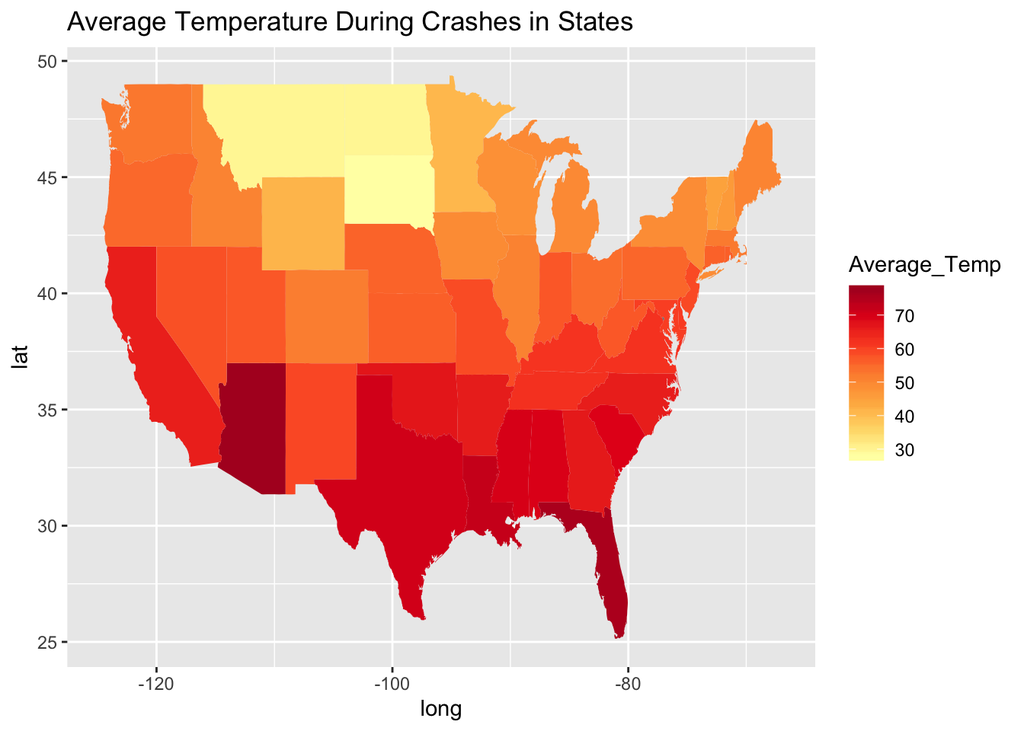

```r
TempChloropleth %>% ggplot(aes(x = long, y = lat, group = group, fill = Average_Temp)) + geom_polygon() + ggtitle("Average Temperature During Crashes in States") + scale_fill_distiller(palette = 'YlOrRd', direction = 1)
```

```r
Top7Hottest <- Temp %>% arrange(desc(Average_Temp))  %>% head(7)
Top7Coldest <- Temp %>% arrange(Average_Temp) %>% head(7)
Top7Hottest
```

```
## # A tibble: 7 x 2
##   State Average_Temp
##   <chr>        <dbl>
## 1 AZ            77.6
## 2 FL            75.9
## 3 LA            72.2
## 4 TX            70.7
## 5 MS            69.7
## 6 AL            69.3
## 7 SC            68.6
```

```r
Top7Coldest
```

```
## # A tibble: 7 x 2
##   State Average_Temp
##   <chr>        <dbl>
## 1 SD            27.9
## 2 ND            29.8
## 3 MT            29.8
## 4 MN            40.9
## 5 WY            41.5
## 6 VT            44.6
## 7 NH            46.3
```

```r
Temp1 <-final %>% mutate(Month = month(Date))
Summer <- Temp1 %>% filter(Month %in% c(6,7,8)) %>% group_by(State) %>% mutate(Number_of_Accidents_State = n(), Average_Temp_in_Season = mean(`Temperature(F)`))
Winter <- Temp1 %>% filter(Month %in% c(12,1,2)) %>% group_by(State) %>% mutate(Number_of_Accidents_State = n(), Average_Temp_in_Season = mean(`Temperature(F)`))
StatePopulation <- final %>% select(POPESTIMATE2019, State, County) %>% distinct(County, .keep_all = TRUE) %>% group_by(State) %>% summarize(State_Population = sum(POPESTIMATE2019))

Summer <- Summer %>% left_join(statePop) %>%
  mutate(Accidents_Per_1000 = Number_of_Accidents_State/POPESTIMATE2019STATE*1000) %>%
  distinct(State, .keep_all = TRUE) %>% select(State,Accidents_Per_1000, Average_Temp_in_Season) %>%
  mutate(Temperature_Throughout_Year = if_else(State %in% Top7Coldest$State, "Coldest", if_else(State %in% Top7Hottest$State, "Hottest", "In Between"))) %>% mutate(Season = 'Summer')
Winter <- Winter %>% left_join(statePop) %>%
  mutate(Accidents_Per_1000 = Number_of_Accidents_State/POPESTIMATE2019STATE*1000) %>%
  distinct(State, .keep_all = TRUE) %>% select(State,Accidents_Per_1000, Average_Temp_in_Season) %>%
  mutate(Temperature_Throughout_Year = if_else(State %in% Top7Coldest$State, "Coldest", if_else(State %in% Top7Hottest$State, "Hottest", "In Between"))) %>% mutate(Season = 'Winter')
full <- Summer %>% full_join(Winter)
```

[output not shown]

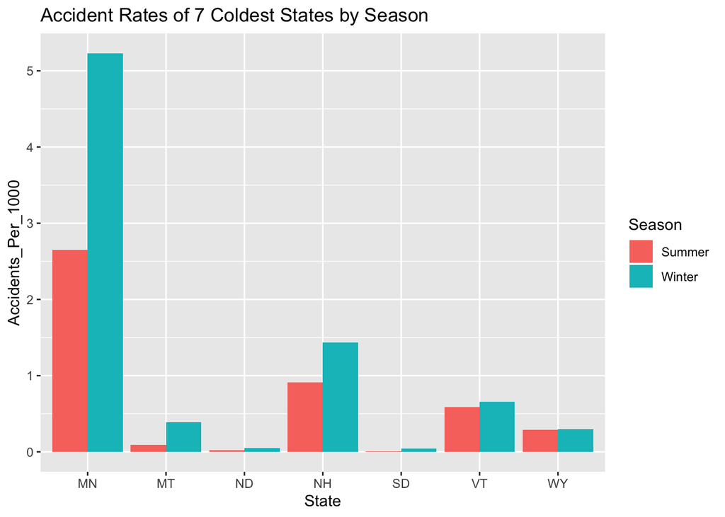

```r
full$Season <- factor(full$Season)
ColdestStates <- full %>% filter(Temperature_Throughout_Year == "Coldest")
HottestStates <- full %>% filter(Temperature_Throughout_Year == "Hottest")
ColdestStates %>% ggplot(aes(x = State, y = Accidents_Per_1000, fill = Season)) + geom_bar(position= "dodge", stat = 'identity') + ggtitle("Accident Rates of 7 Coldest States by Season")
```

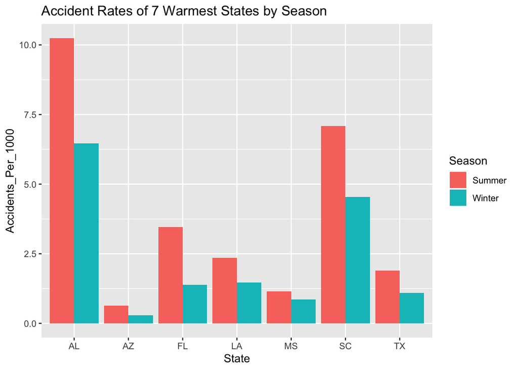

```r
HottestStates %>% ggplot(aes(x = State, y = Accidents_Per_1000, fill = Season)) + geom_bar(position= "dodge", stat = 'identity') + ggtitle("Accident Rates of 7 Warmest States by Season")
```

First figure out the average temperature for each state and then group them into high and low temperature states by splitting them in half

(Cole) 4. Show the distribution of visibility in traffic accidents in the US. What does the distribution tell us about the effects that different visibility levels have on how many traffic accidents occur?

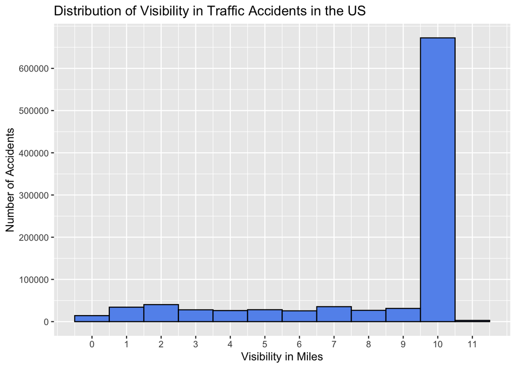

```r
crashData %>% mutate(x_new = ifelse(`Visibility(mi)` > 11.5, 11.5, `Visibility(mi)`)) %>% ggplot(aes(x_new)) + geom_histogram(binwidth = 1, col = "black", fill = "cornflowerblue") + scale_y_continuous(breaks = seq(0, 600000, 100000),labels = function(x) format(x, scientific = FALSE)) + scale_x_continuous(breaks = seq(0, 11, 1)) + labs(title="Distribution of Visibility in Traffic Accidents in the US",x="Visibility in Miles",y="Number of Accidents")
```

(Charlie) 5. What are the most common weather conditions that occur during accidents? What states do these weather conditions occur at the highest rate in and are these states generally near the top of traffic accident rates when including all weather conditions?

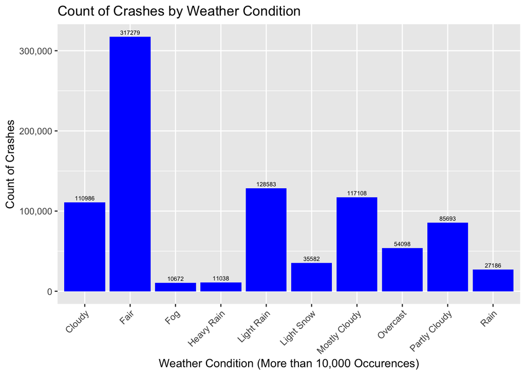

```r
crashData %>% group_by(Weather_Condition) %>% filter(n() > 10000) %>%
  ggplot(aes(x=Weather_Condition)) + geom_bar(fill='blue') +
  geom_text(stat='count', aes(label=stat(count), vjust = -.5), size=2) +
  theme(axis.text.x = element_text(angle=45, vjust=1, hjust=1)) +
  scale_y_continuous(labels=scales::comma) + xlab("Weather Condition (More than 10,000 Occurences)") +
  ylab("Count of Crashes") + ggtitle("Count of Crashes by Weather Condition")
```

*This graph shows the most common weather patterns during accidents throughout the United States. I will now see how each state is affected by these weather events.*

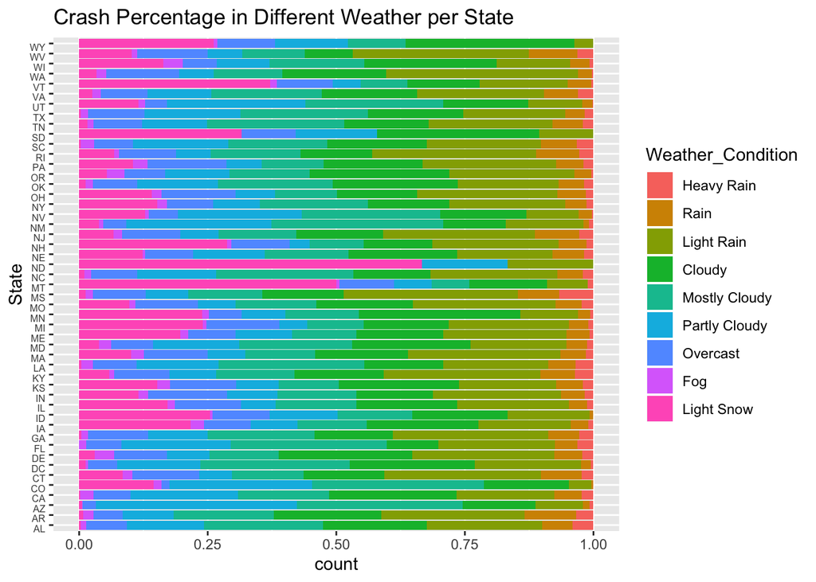

```r
#Remove "fair", since the goal here is to identify crashes due to weather anomalies
commonWeather <- crashData %>% filter(
        Weather_Condition == 'Cloudy' | Weather_Condition == 'Light Rain' |
        Weather_Condition == 'Light Snow' | Weather_Condition == 'Mostly Cloudy' |
        Weather_Condition == 'Partly Cloudy' | Weather_Condition == 'Fog' |
        Weather_Condition == 'Heavy Rain' | Weather_Condition == 'Rain' |
        Weather_Condition == 'Overcast')
commonWeather <- commonWeather %>% group_by(State) %>% left_join(statePop, by='State')
commonWeather <- commonWeather %>% mutate(n = n()) %>%
  mutate(crashRate = n / POPESTIMATE2019STATE)
commonWeather$Weather_Condition <-
  factor(commonWeather$Weather_Condition,
         levels = c("Heavy Rain", "Rain", "Light Rain", "Cloudy", "Mostly Cloudy", "Partly Cloudy", "Overcast", "Fog", "Light Snow"))
commonWeather %>% ggplot(aes(x=State)) + coord_flip() +
  geom_bar(aes(fill=Weather_Condition), position="fill") +
  theme(axis.text.y = element_text(vjust=1, hjust=1, size=6)) +
  ggtitle("Crash Percentage in Different Weather per State")
```

*It appears that states differ greatly in terms of how weather events affect them. North Dakota and Montana, for example, have close to or more than half of all crashes in their states during a snowy or foggy scenario.*

(Juan) 6. What is the relationship between the amount of precipitation on the ground and the amount of accidents that happen? How does this relationship vary when conditioned on different types of precipitation(Snow, Sleet, Rain)?

(Juan) 7. Between the first year and last year how have accident rates changed over all counties in the US? What counties accident rate has increased the most and which has decreased the most? What may be the reason for this?

For the reasoning lookup possible events that occured in the news in those counties in between the time start and end time that may have influenced such a drastic change